# Analysis of School Shootings in the US 1990 - 2021

## Map Of Most States With High Shooting Fatalities.

I created a simple map to visualise the States with most shooting fatalities:

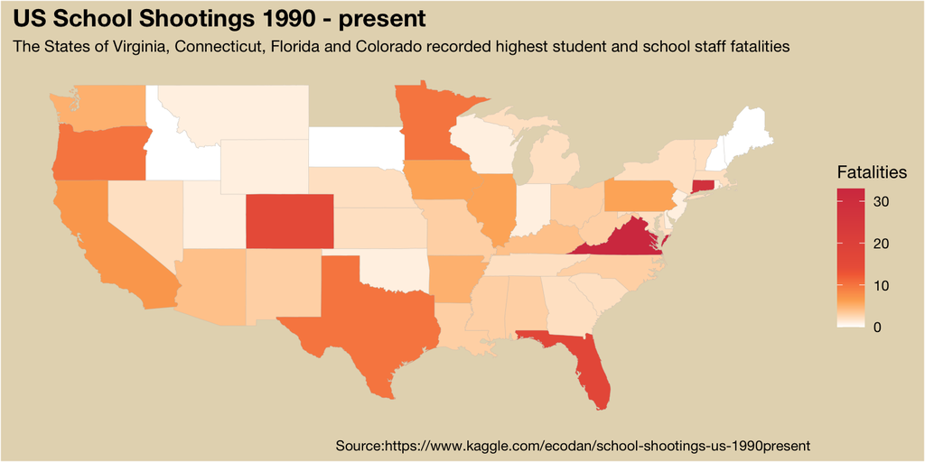

A quick historical review over the years on known shooting incidents with highest fatalities:

- The Columbine High School massacre incident took place at State of Colorado.
- The Virginia Tech shooting incident took place at State of Virginia.
- The Sandy Hook Elementary School shooting took place at State of Connecticut.
- Recently, Marjory Stoneman Douglas High School shooting took place at State of Florida.

## School shooting by city

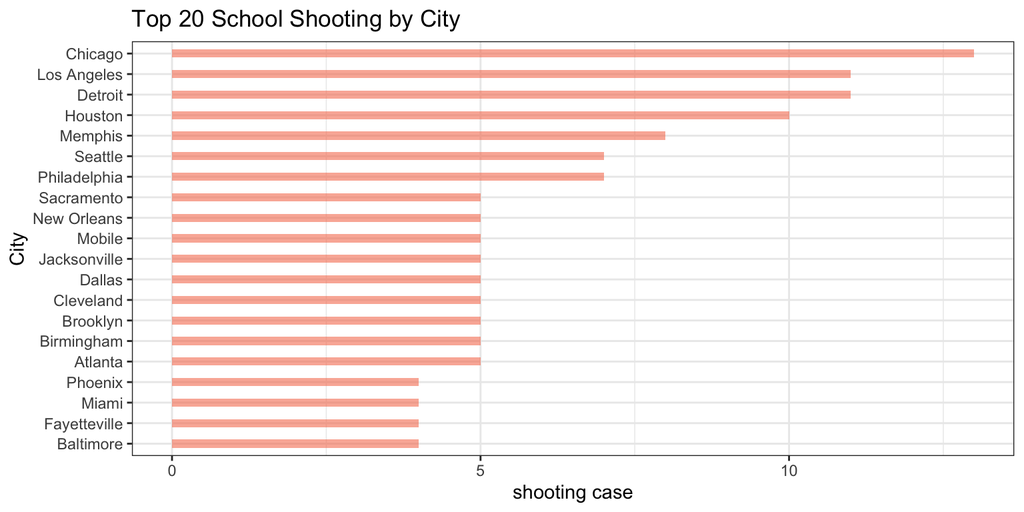

We can see from the Bar plot above that Chicago has the most school shootings of 13 cases on record during the period of 1990 – 2021 YTD, where Los Angles and Detroit both 11 cases, and Houston had 10. Since there are too many cities in the database, we can focus on School shootings by State as well.

## School shooting by state

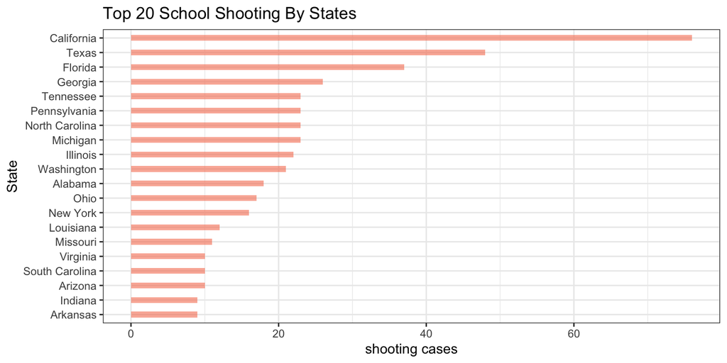

During the period of 1990 – 2021 YTD, there are a total of 76 cases of shoot shootings reported in the states of California, followed by 48 cases in Texas and 37 cases in Florida. We observe a big gap in school shooting cases between California with the rest of the states.

## School shooting by school type

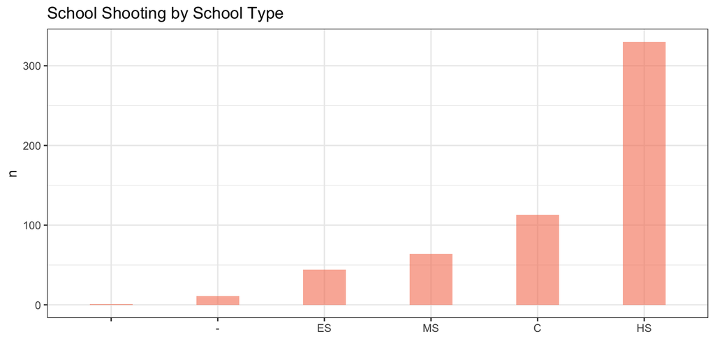

In the period of 1990 – 2021 YTD, most school shooting cases happened in High School, followed by college, and then Middle school, lastly elementary school. There was a total of 330 School shootings cases happened in High school, more than the sum of all school shootings occurred in other school types.

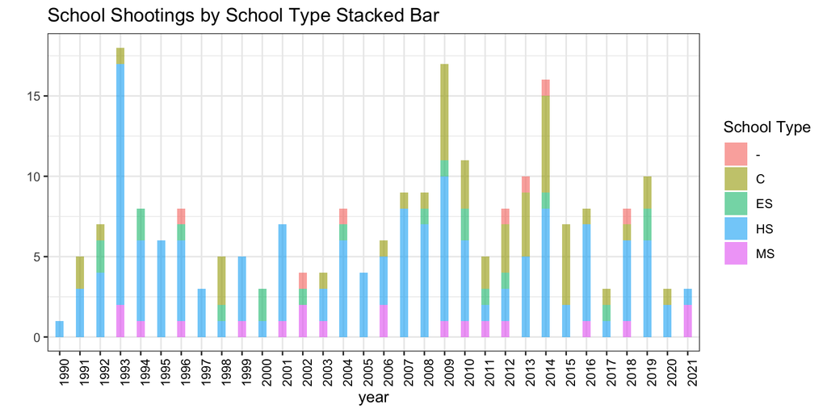

## School shooting by Fatalities

[figure not shown]

## School shooting by areatype

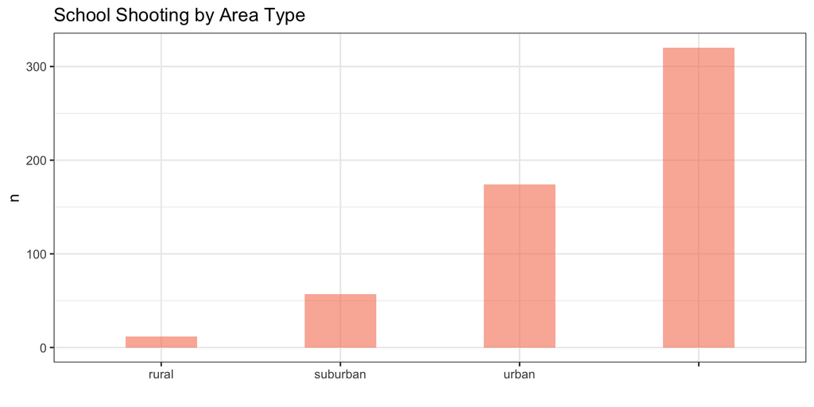

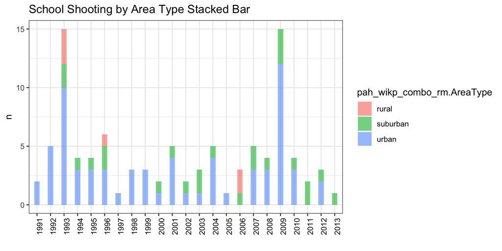

We have a lot of null values for Area Type column. However, with the available data above, we are still able to see that most shooting cases took place in urban areas and less took place in rural areas.

# Distribution of Data

## Distribution of Yearly Shootings

Annual school shootings were already observed. This shows a large picture of what occurs each year. This might show a more realistic view as to what is going on. One of the first question asked is what is the yearly school shooting statistics. This information was not provided in the initial data frame.

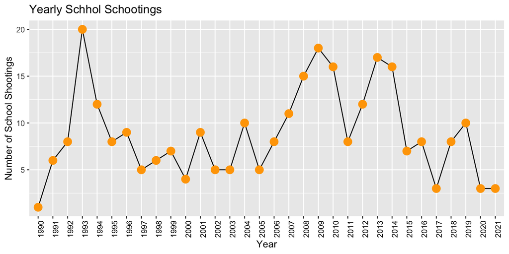

## School Schootings by Year and Month

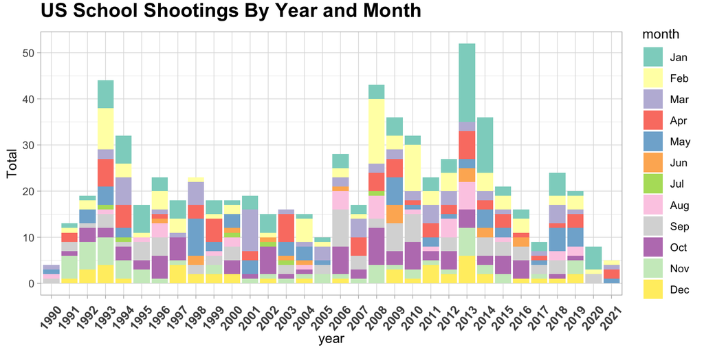

We find:

- During 2013 and 2014, many shootings had occured during the 1st month of the year(January).
- We can also see that many shootings occured during the 1st and 2nd month of the year starting from 2008 until 2014.

## School Shootings by Year and Weekdays

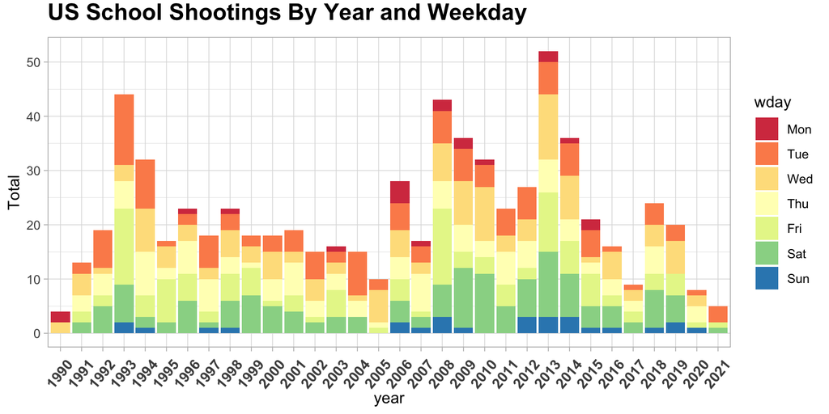

We find:

- Most of the shooting incidents occured during the weekdays starting from the 4th day until the 6th day of the week (Thursday until Saturday), with many incidents happening during Fridays and Saturdays.

## Distribution by Cities and School Types

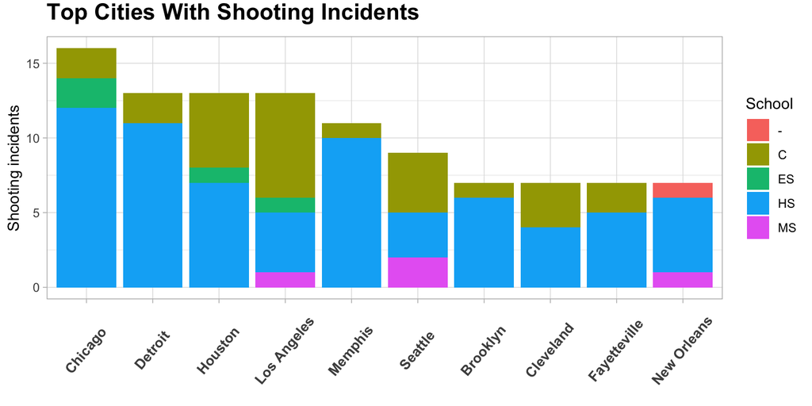

We find:

- Majority of shootings occured at HS / High Schools followed by “C” / College campuses.

## Distribution by Cities and Areatypes

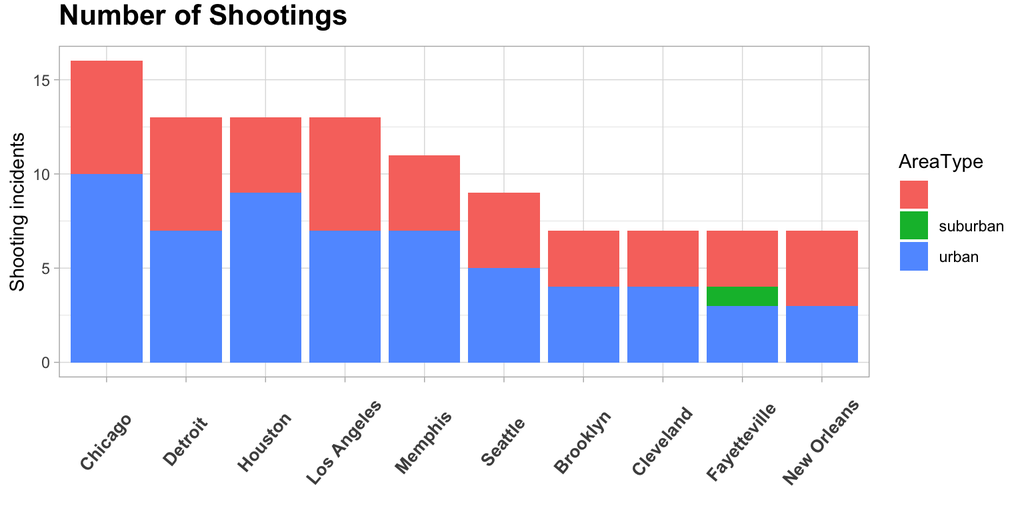

We find:

- Most shootings occured at urban areas, not surprising anyway.

# Central Limit Theorem

The Central Limit Theorem states that the distribution of the sample means for a given sample size of the population has the shape of the normal distribution. The theorem is shown with various distributions of the input data in the following sections. In other words, as the sample size gets larger, the means of the samples become a normal distribution. This was tested against the different years’ distributions of the total enrolled school population. Below is a figure showing the distributions of 1000 random samples of sample sizes of 10, 20, 30, and 40.

```
## Population mean: 63353.49 Standard Deviation: 11114.76
```

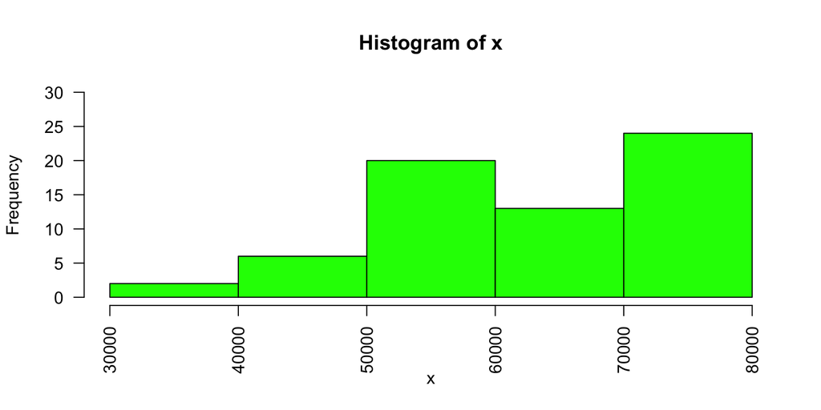

```
## Sample Size =  10  Mean =  63355.24  SD =  3125.924
```

```
## Sample Size =  20  Mean =  63285.87  SD =  2038.993
```

```
## Sample Size =  30  Mean =  63252.55  SD =  1471.357
```

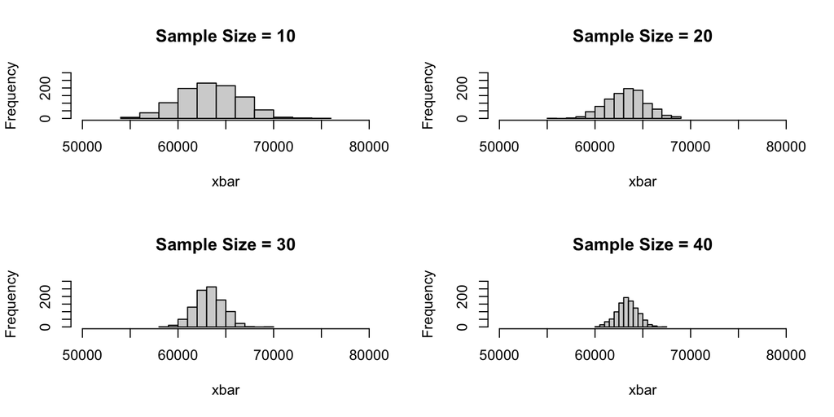

```
## Sample Size =  40  Mean =  63381.47  SD =  1085.349
```

# Sampling

Sampling is used to identify and analyze any trends or patterns that can be seen in a subset of a larger group of data. It can also be a useful technique to help predict some type of data or information. There are many different types of sampling that can be applied to data. The sampling methods used for this analysis are simple random sampling without replacement, systematic, and stratified. The sampling was specifically looking at the type of the schoools in the school shooting accident. Simple random sampling is when a specified sample is selected from the larger group or larger frame. Each person or object has an equivalent opportunity of getting selected. The sample size of 50 is being used. Out of the population of 700, there will be 50 randomly selected without replacement. Another technique that was used to sample the data was stratified sampling. Stratified sampling is when the larger group of data is broken into smaller groups and then certain sizes are picked from each group. In this analysis, the school types are broken into each group and random types are selected from each group. The final technique of sampling used for the analysis is systematic sampling. Systematic sampling is when there are “rules” decided to pick the sample size. There is a potential bias with this type of sampling. For each one of these sampling techniques, a sample size of 50 was used.

```
## Frequency of school type
```

```
##
##   -   C  ES  HS  MS
##  11 145  51 402  91
```

```
## Percentage of school type
```

```
##
##    -    C   ES   HS   MS
## 0.02 0.21 0.07 0.57 0.13
```

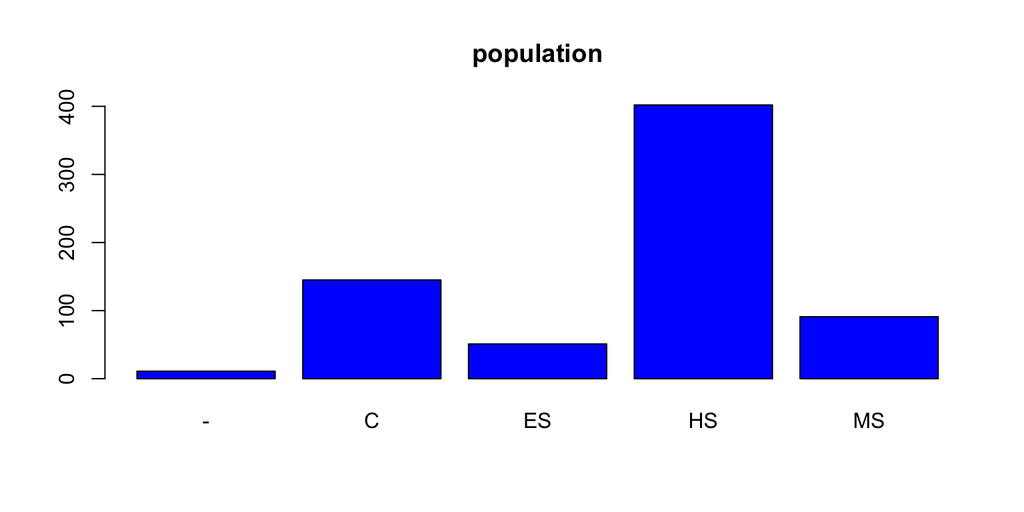

```
## Frequency of school type
```

```
##
##  C ES HS MS
## 15  3 26  6
```

```
## Percentage of school type
```

```
##
##    C   ES   HS   MS
## 0.30 0.06 0.52 0.12
```

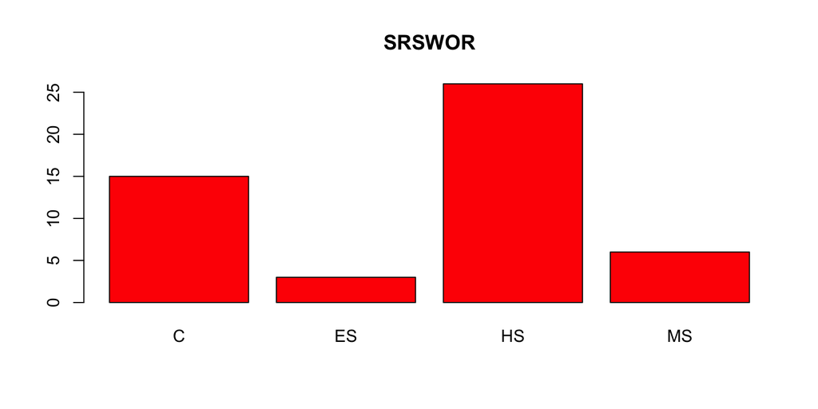

```
## Frequency of school type
```

```
##
##  C ES HS MS
##  6  7 26 11
```

```
## Percentage of school type
```

```
##
##    C   ES   HS   MS
## 0.12 0.14 0.52 0.22
```

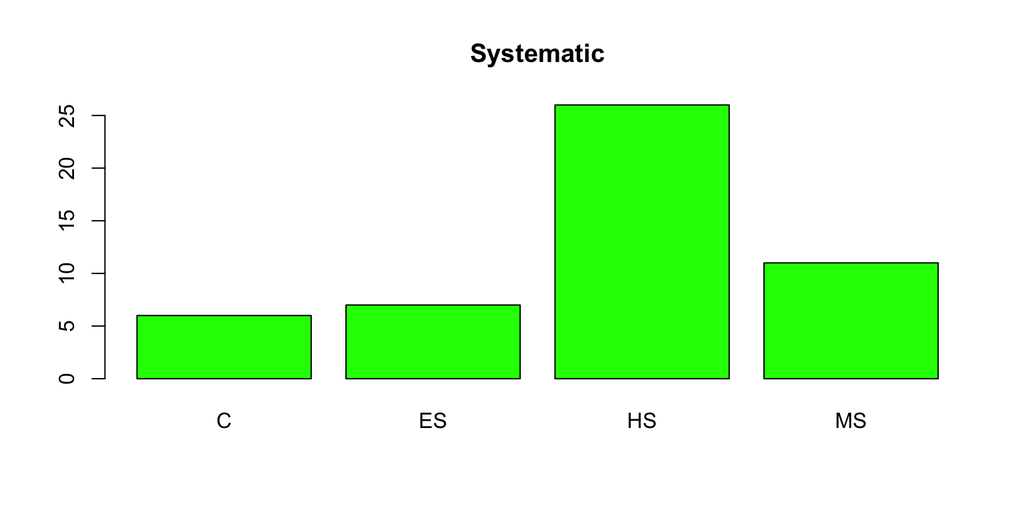

```
## Frequency of school type
```

```
##
##  -  C ES HS MS
##  1 10  4 29  6
```

```
## Percentage of school type
```

```
##
##    -    C   ES   HS   MS
## 0.02 0.20 0.08 0.58 0.12
```

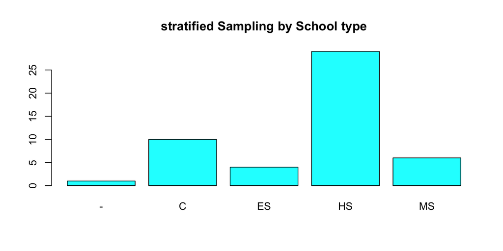

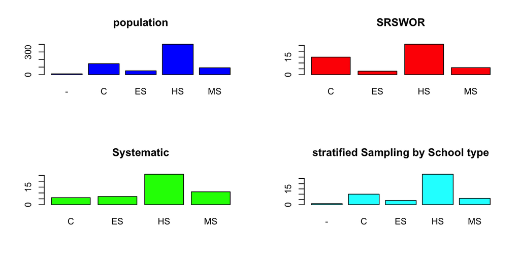

```
## Population: Unknown 2% of the school type.  SRSWOR: Unknown 0% of the school type
```

```
## Population: College 21% of the school type.  SRSWOR: College 30% of the school type
```

```
## Population: Elementary School 7% of the school type.  SRSWOR: Elementary School 6% of the school type
```

```
## Population: High School 57% of the school type.  SRSWOR: High School 52% of the school type
```

```
## Population: Middle School 13% of the school type.  SRSWOR: Middle School 12% of the school type
```

```
## Population: Unknown 2% of the school type.  Systematic Sample: Unknown 0% of the school type
```

```
## Population: College 21% of the school type.  Systematic Sample: College 12% of the school type
```

```
## Population: Elementary School 7% of the school type.  Systematic Sample: Elementary School 14% of the school type
```

```
## Population: High School 57% of the school type.  Systematic Sample: High School 52% of the school type
```

```
## Population: Middle School 13% of the school type.  Systematic Sample: Middle School 22% of the school type
```

```
## Population: Unknown 2% of the school type. Stratified Sample: Unknown 2% of the school type
```

```
## Population: College 21% of the school type.  Stratified Sample: College 20% of the school type
```

```
## Population: Elementary School 7% of the school type.  Stratified Sample: Elementary School 8% of the school type
```

```
## Population: High School 57% of the school type.  Stratified Sample: High School 58% of the school type
```

```
## Population: Middle School 13% of the school type.  Stratified Sample: Middle School 12% of the school type
```

Overall, the sampling shows similarity to the population. Random select sampling without replacement is a little bit of the model. As we can see, shooting accidents happen most in high school and least at elementary school. It makes sense to us since when we heard about shooting accidents in school, most time it happens in high school.

# Conclusion

Noting our previous observations from notable shooting incidents with highest fatalities:

- The Columbine High School massacre incident took place at State of Colorado.
- The Virginia Tech shooting incident took place at State of Virginia.
- The Sandy Hook Elementary School shooting took place at State of Connecticut.

We can see that most of the shooting incidents took place on “HS” highschool campuses. Basing on our data at hand, most highschool students are at risk of possibility of shooting incidents.